# Powbal India - Spring 23 Dashboard

2023-03-01

Last update 2023-03-01 17:48:36

This page provides basic statistics and information on the POWBAL PAUSE Demand Pilot in India.

### Registered users over time

In total we have 75 who registered with the POWBAL app since summer 2022. 38 also succesfully configured a plug that came online at some point.

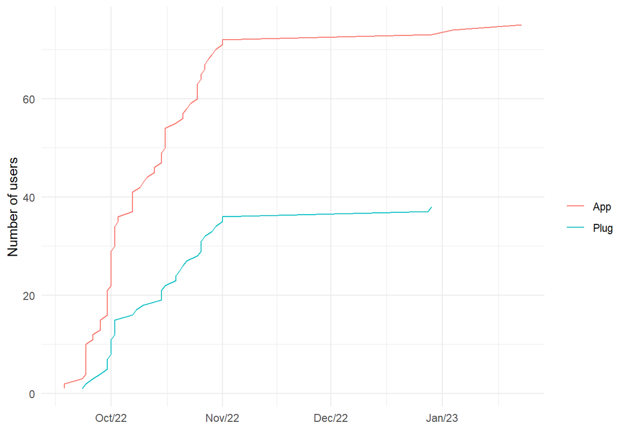

### Distribution of Power consumption

Most participating household connect fairly power hungry devices to the plugs at least some of the time. The Figure below shows the distribution of maximum power connected across plugs. This average at 1125 Watt. Note that the distribution is bimodal. There is a concentration of users at below 1kWh. However, there is also a fairly big mass above 2kWh. Users in that range must have connected a fairly substantial air-conditioning unit or similar.

Mean power consumption is naturally much lower and highly concentrated near 0. That said: for some users even the unconditional average is above 1kW; i.e. they are connecting an air conditioning unit or similar in most periods.

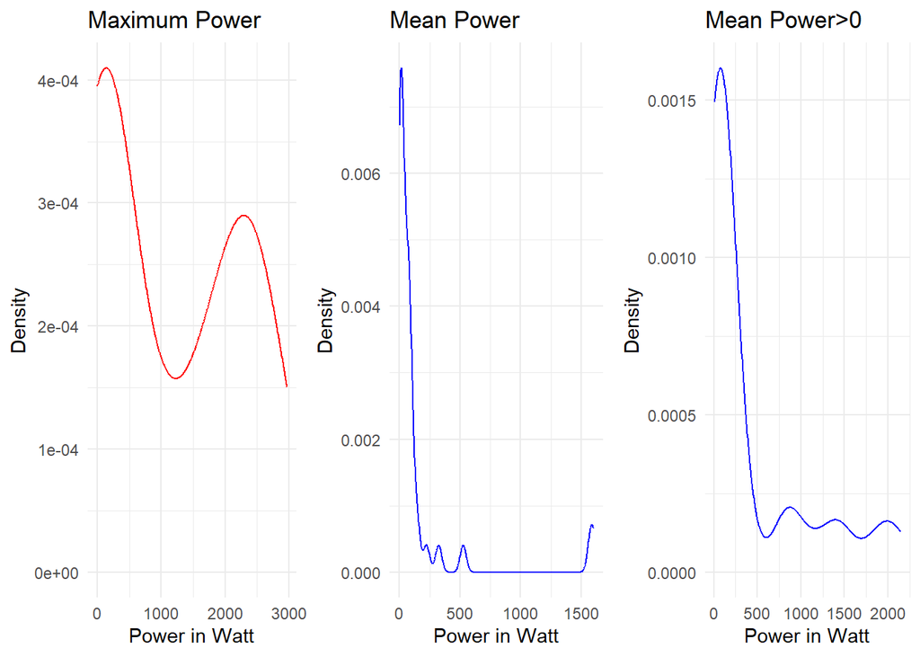

### Basic time series - A bird’s eye view on the whole pilot trial…..

#### Plugs Connected:

[interactive chart not shown]

#### Energy consumed (Wh):

[interactive chart not shown]

### Hours of the day

Average figures by hour of the day. This gives us an idea if users are providing more shifting potential by the hour of the day.

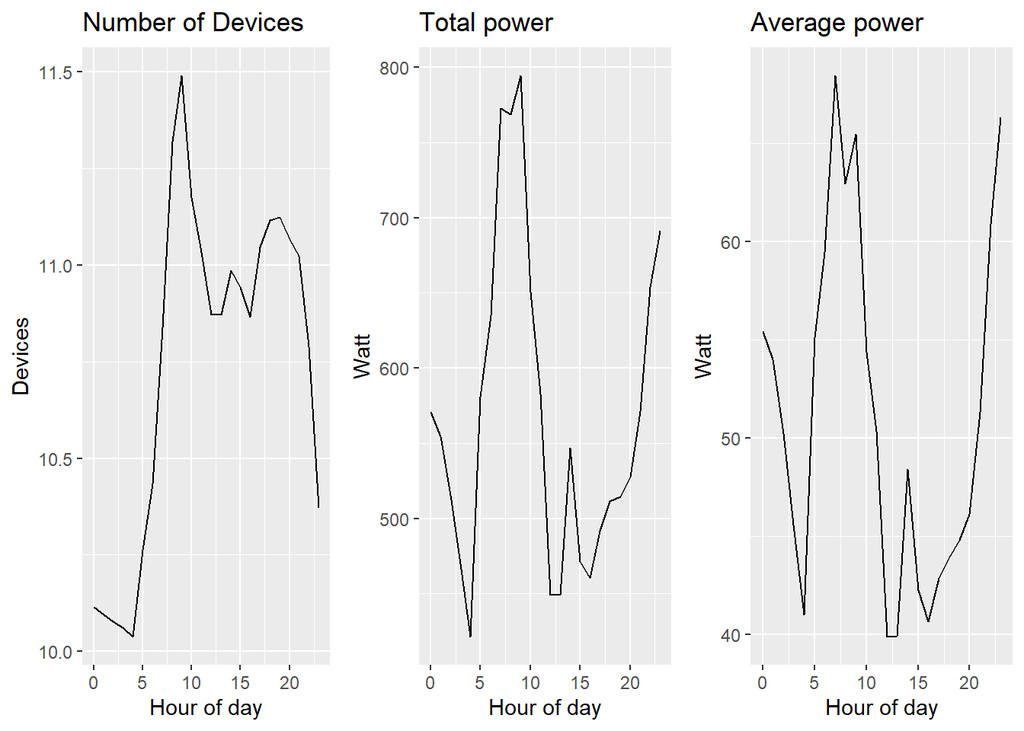

### The anatomy of switch off events…..

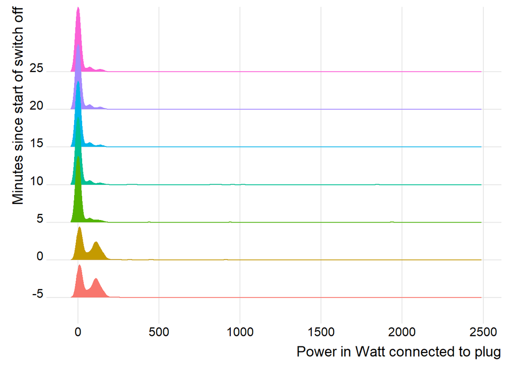

We see that most switch off events are successful; i.e. users typically do not override. This is based on 1361 events across all users with non zero consumption at the start of the event. In total we had 8424 switch off events across online plugs.

### Virtual power plant capacity factors

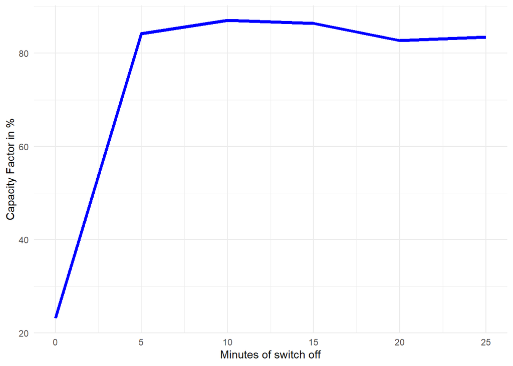